# Partição de variação: uma espécie

Exercício prático da disciplina Ecologia de Populações de Comunidades Vegetais, IB-USP

# Introdução

Os três parâmetros estruturais básicos das comunidades são a riqueza, composição e abundância (de espécies, tipos funcionais, linhagens …). Uma das abordagens da ecologia de comunidades é buscar regularidades nestes parâmetros estruturais, e propor explicações para eles. Neste roteiro vamos aprender uma das ferramentas estatísticas usadas para isto, chamada **partição de variação**.

Podemos tentar entender as comunidades analisando cada uma das populações de cada espécie presente ou podemos tentar entender o conjunto de espécies como um todo. Aqui vamos analisar a estrutura espacial da abundância de uma espécie fictícia. Começamos com apenas uma espécie porque isso facilita entender os cálculos e suas interpretações. No roteiro seguinte mostraremos como a partição pode ser generalizada para descrever padrões conjuntos de abundância de muitas espécies.

## Preparação

Para fazer este roteiro você precisa ter feito antes o roteiro sobre coeficiente de determinação.

Para começar, abra o R e cole o comando abaixo na linha de comando e pressione *“Enter”*:

```r
dados <- read.csv("https://raw.githubusercontent.com/piLaboratory/BIE-0320/main/data/roteiro1b.csv")
```

Se não houve nenhuma mensagem de erro agora você tem no R uma tabela com 100 linhas e três colunas, que explicaremos a seguir. Se quiser dar uma olhada na tabela, você pode usar os comandos seguintes para mostrar suas primeiras e últimas linhas:

```r
head(dados)
```

```
##   abund       pH space
## 1     5 7.424995  0.10
## 2     5 7.447757  0.15
## 3    11 7.478305  0.20
## 4    10 7.510168  0.25
## 5    11 7.539322  0.30
## 6     7 7.559655  0.35
```

```r
tail(dados)
```

```
##     abund       pH space
## 95     19 7.646624  0.75
## 96     20 7.694641  0.80
## 97     28 7.689214  0.85
## 98     26 7.719794  0.90
## 99     36 7.760034  0.95
## 100    21 7.800000  1.00
```

# Em busca de uma estrutura

A abundância de uma espécie pode variar muito, no tempo e no espaço. A pergunta fundamental aqui é o que causa esta variação. A partição de variância é um método para avaliar o quanto da variação de uma quantidade pode ser atribuída à variação de uma outra quantidade. Usamos esse método para avaliar se é plausível que a abundância de uma planta em uma área varie em função da variação de um fator ambiental, por exemplo.

### Um padrão

Vamos aos nossos dados, para deixar mais concreto. A figura abaixo representa uma parcela permanente, que foi dividida em 100 quadrados. Em cada quadrado foram contados todos os indivíduos de *Non illum*, uma erva daninha invasora. A abundância da planta por quadrado vai de dois indivíduos (cinza claro) até 41 indivíduos (cor preta).

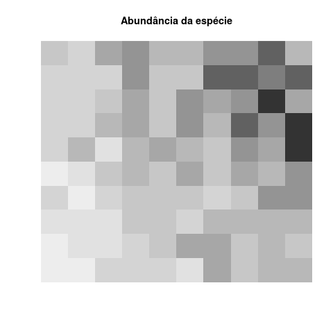

## Uma hipótese: variação ambiental

Percebendo a concentração de plantas no canto superior direito da parcela, uma ecóloga propôs a hipótese de que a planta tem uma associação com solos menos ácidos. Ela chegou a esta hipótese porque havia medido o pH do solo superficial em cada parcela, o que usou para fazer o mapa a seguir (à direita). Neste mapa, cores claras são valores mais baixos de pH e cores escuras valores altos.

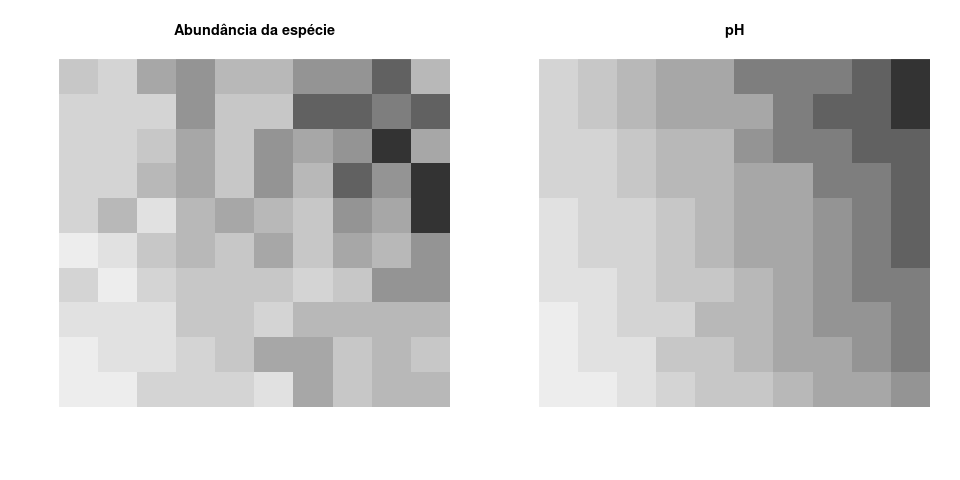

Parece razoável? Para avaliar melhor isto vamos fazer um gráfico da relação entre a abundância da planta e o valor do pH em cada parcela. Já importamos estes dados para o R na seção anterior, então temos só que executar um comando no R para ver o gráfico:

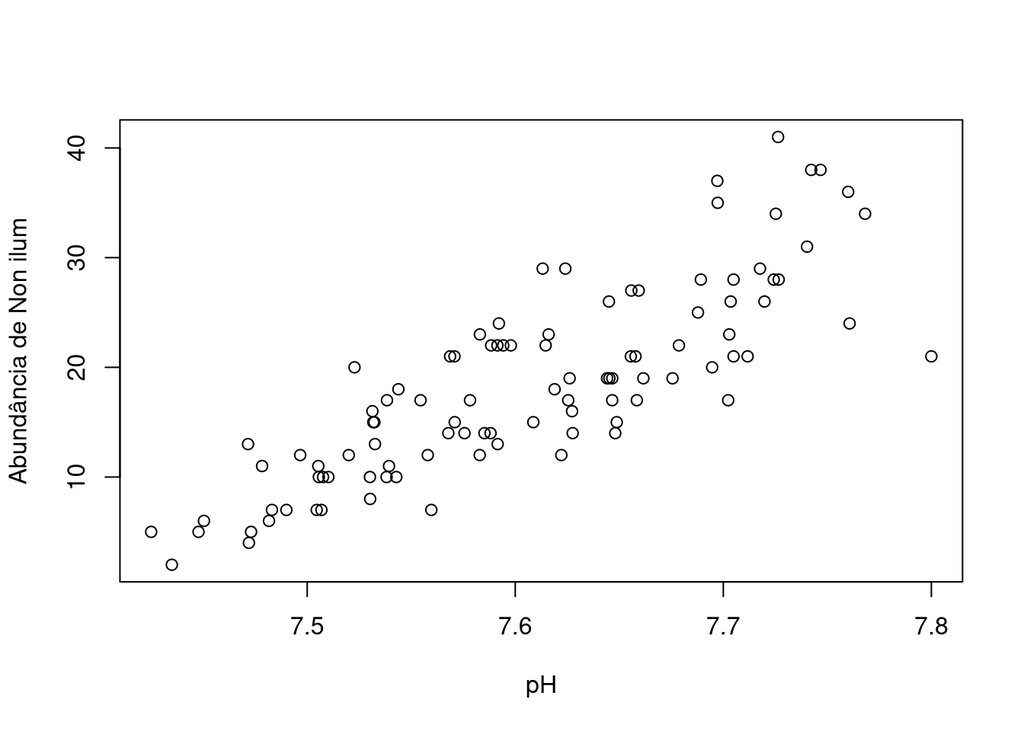

```r
plot(abund ~ pH, data = dados,
     ylab= "Abundância de Non ilum")
```

O gráfico sugere que a abundância da planta é proporcional ao pH. Se isso é verdade, deve haver uma linha reta que aproxime bem essa relação. A **regressão linear** é uma técnica estatística para encontrar essa reta. Execute no R o comando para ajustar a regressão da abundância em função do pH:

```r
regr.pH <- lm(abund ~ pH,  data = dados)
```

E adicione a linha da regressão ao seu gráfico com

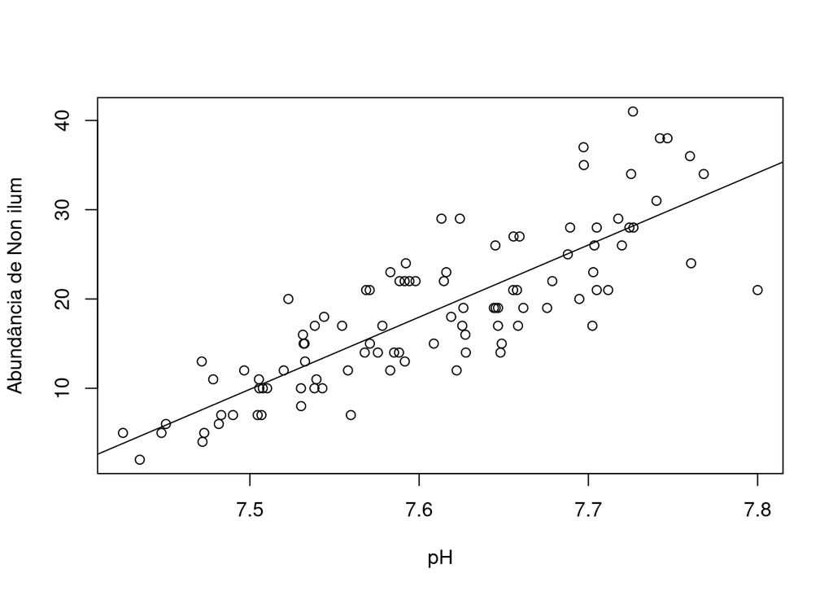

```r
plot(abund ~ pH, data = dados,
     ylab= "Abundância de Non ilum")
abline(regr.pH)
```

### A variação explicada pela hipótese

A regressão linear nos retorna várias informações importantes sobre a relação que hipotetizamos. A que mais nos interessa agora é o **coeficiente de determinação**, expresso pela sigla $R^2$. Esse coeficiente expressa a proporção da variação total da variável resposta (a abundância, no caso) que é “capturada” ou “explicada” pela variação da variável explanatória (o pH, no caso)[^1].

Para obter o $R^2$ da regressão que ajustamos acima basta executar o comando, que também guarda o valor obtido no objeto `X`:

```r
(X <- summary(regr.pH)$r.squared)
```

```
## [1] 0.6857125
```

O resultado nos mostra que 68.6% da variação da abundância da espécie é explicada por uma relação linear com o pH do solo superficial.

## Outra hipótese: limitação à dispersão

Uma outra ecóloga sabia que a invasão por *Non illum* era recente e havia começado pelo canto superior direito da parcela por sementes trazida acidentalmente por tucanos, que desapareceram em seguida [^2]. A ecóloga então propôs que quadrados mais distantes do ponto de entrada tiveram menor chance de serem colonizados. Essa hipótese propõe que a variação da abundância desta planta observada na parcela é resultado apenas da limitação à dispersão. A ecóloga criou então um mapa para expressar sua hipótese. Nesse mapa (à direita) os quadrados com maior chance de receber propágulos estão em tons mais escuros:

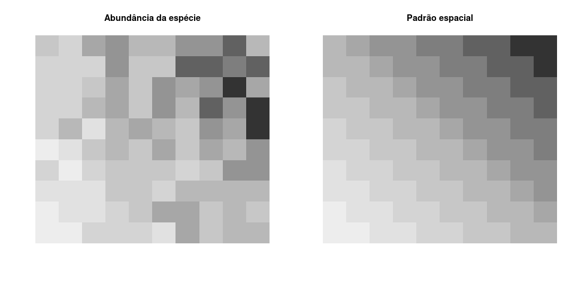

Este é mapa é construído atribuindo um valor a cada quadrado, que é um índice de abundância relativa aos demais quadrados. No caso, esse índice de abundância pode ser interpretado como proporcional à probabilidade de estabelecimento de um propágulo. A limitação à dispersão se expressa pelo arranjo espacial de áreas com alta e baixa probabilidade de estabelecimento, de acordo com algum modelo de dispersão ou estabelecimento. Neste caso o modelo é bem simples: quanto mais distante do vértice superior direito, menor a chance de estabelecimento. Por isso vamos chamar o índice usado para construir o mapa de **variável de estrutura espacial**. Os valores dessa variável também já estão no arquivo que importamos para o R anteriormente.

Compare o mapa da direita com o mapa de variação da abundância da planta (esquerda). Será que a limitação à dispersão proposta é uma boa hipótese? Para ajudar, faça o gráfico da abundância em função da variável de estrutura espacial com o comando:

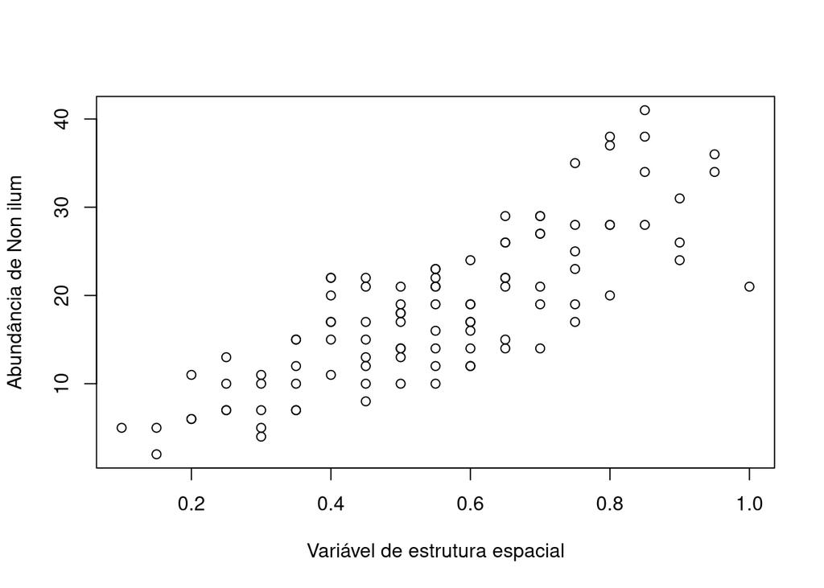

```r
plot(abund ~ space, data= dados, xlab = "Variável de estrutura espacial",
      ylab= "Abundância de Non ilum")
```

### Teste da hipótese de limitação à dispersão

Para testar esta nova hipótese ajustamos a regressão da abundância em função da variável espacial:

```r
regr.space <- lm(abund ~ space, data = dados)
```

E podemos adicionar a linha da regressão ao gráfico:

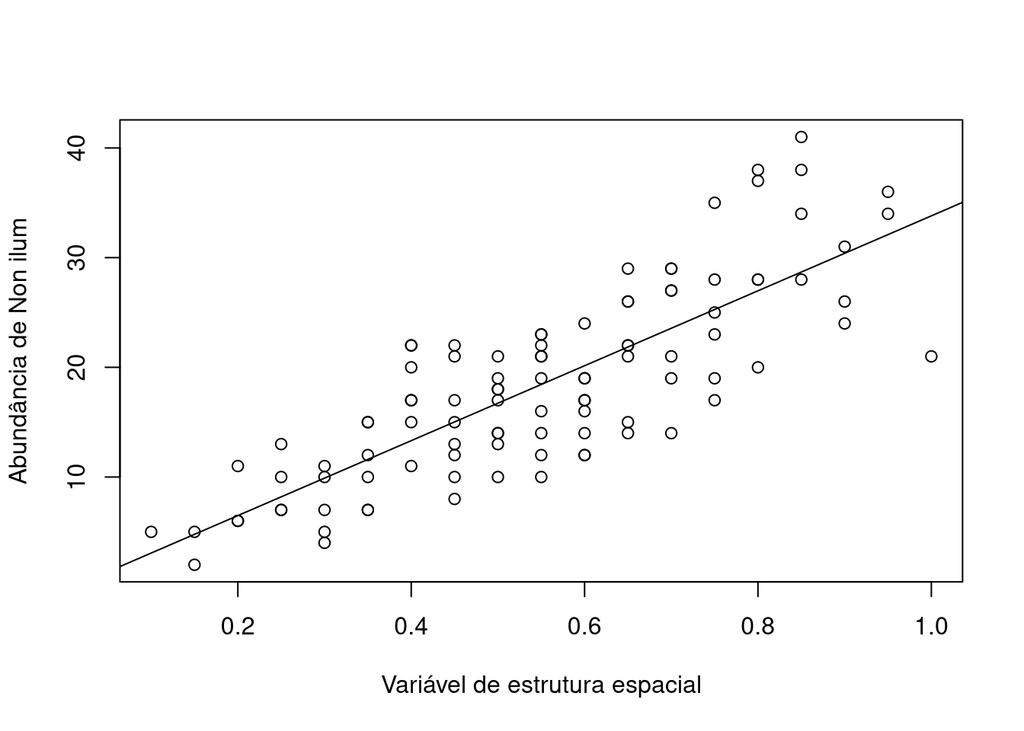

```r
plot(abund ~ space, data= dados, xlab = "Variável de estrutura espacial",
      ylab= "Abundância de Non ilum")
abline(regr.space)
```

### Variação explicada pela hipótese de limitação à dispersão

Obtemos a fração da variação da abundância explicada pela variável espacial com o comando que já conhecemos, aplicado ao objeto que guarda os resultados da regressão:

```r
(W <- summary(regr.space)$r.squared)
```

```
## [1] 0.6552809
```

## Partição da variação entre ambiente e espaço

Resumindo o que encontramos até aqui: uma variável ambiental (pH) explica 69% da variação da abundância da espécie. Mas uma variável de estrutura espacial explica 66% dessa mesma variação. Como é possível que a soma dos percentuais de variação explicada passem de 100% ?

A resposta é que há uma relação entre o pH e a variável de estrutura espacial:

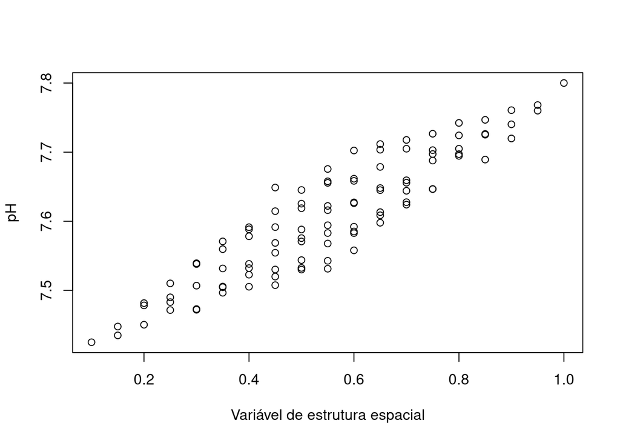

```r
plot(pH ~ space, data = dados, xlab = "Variável de estrutura espacial")
```

O que significa que **a variável ambiental tem uma estrutura espacial**, que é bem descrita pela estrutura espacial proposta pela segunda hipótese. Assim, a variação explicada pelo pH contém uma parte de efeito espacial. Da mesma forma, uma parte da variação explicada pela variável espacial contém efeito do pH.

A essa parte da variação compartilhada chamamos **variação ambiental estruturada no espaço**. No esquema abaixo, essa parte da variação explicada é o componente $b$.

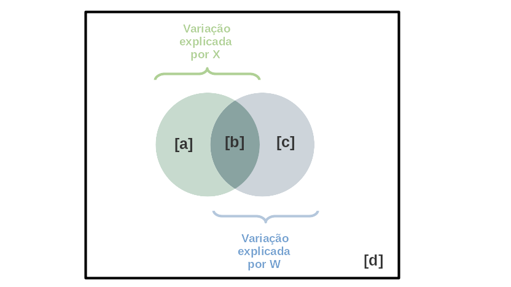

O círculo da esquerda representa a variação explicada por uma variável $X$, no caso a variável ambiental. Vemos que a variação explicada por $X$ é a soma do componente compartilhado com a outra variável ($b$) com o componente $a$, que chamamos **fração de variância explicada apenas pelo ambiente**.

Da mesma forma, o círculo da direita representa a variação explicada por uma segunda variável $W$, no caso o espaço. Vemos que $W$ é a soma do mesmo componente compartilhado $b$ com uma outra fração $c$, que chamamos de **fração de variância explicada apenas pelo espaço**.

Por fim, variação total é representada pelo retângulo externo. A parte não coberta pelos círculos é a variação que não é explicada por nenhuma variável, indicada por $d$.

### Variação não explicada

Ainda falta descobrirmos a fração de variação não explicada nem pelo pH nem pela variável de estrutura espacial. Para fazer isso, precisamos primeiro ajustar a regressão que inclui a soma dos efeitos dessas duas variáveis:

```r
regr.tudo <- lm(abund ~ pH + space, data = dados)
```

Da qual obtemos a variação explicada pelo pH e a variável espacial juntas:

```r
summary(regr.tudo)$r.squared
```

```
## [1] 0.7009386
```

Esta quantidade corresponde a $a+b+c$ no diagrama acima, que vamos chamar de $XW$. Sabendo que a soma de todas as frações de variação é um:

$$a+b+c+d\ = \ XW + d \ = \ 1$$

temos então que

$$d = 1 - XW$$
.

Assim, obtemos $d$ subtraindo o valor de $XW$ de um:

```r
XW <- summary(regr.tudo)$r.squared
1 - XW
```

```
## [1] 0.2990614
```

### Juntando as peças

Agora temos todas as peças que precisamos para calcular como a variação da abundância de *Non illum* pode ser particionada entre os componentes do diagrama acima:

$$\left\{
\begin{array}{l}
a + b = X \\
c + b = W\\
a + b + c = XW\\
1 - d = XW
\end{array}
\right.$$

O que implica em

$$\left\{
\begin{array}{l}
a = XW - W\\
b = X - a\\
c = W - b\\
d = 1 - XW\\
\end{array}
\right.$$

Usando os valores de $X$, $W$ e $XW$ que já calculamos e guardamos no R temos então:

**Fração devido apenas a pH ($a$):**

```r
(a <- XW - W)
```

```
## [1] 0.0456577
```

**Fração devido a espaço e pH ($b$):**

```r
(b <- X - a)
```

```
## [1] 0.6400548
```

**Fração devido apenas a espaço ($c$):**

```r
(c <- W - b)
```

```
## [1] 0.01522611
```

**Fração não explicada ($d$):**

```r
(d <- 1 - XW)
```

```
## [1] 0.2990614
```

# Conclusão

Abaixo o diagram de Venn da partição da variação na abundância de *Non illum* nos componentes que definimos neste roteiro. Verifique se os valores de cada fração corresponde aos que você obteve:

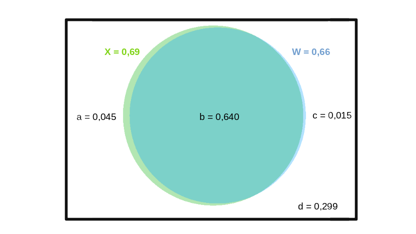

E aqui um gráfico de barra com a proporção das frações $a$, $b$, $c$ desta particão, em uma escala de $R^2 \times 100$:

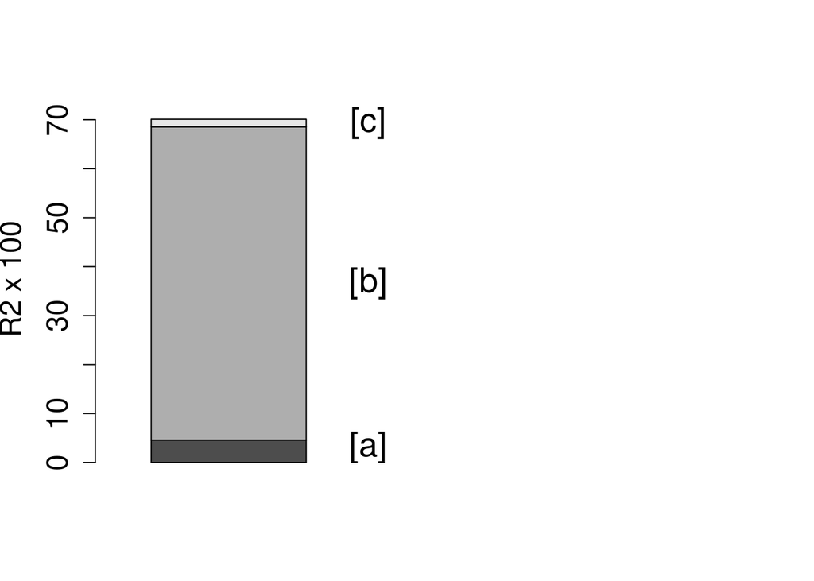

## A pergunta sobre a vida, o universo e tudo mais

Qual hipótese tem mais apoio dos resultados?

[^1]: Para entender o $R^2$ veja o roteiro sobre coeficiente de determinação
[^2]: ao que parece tucanos e patos amarelos dispersam apenas uma vez as sementes, pois morrem envenenados por elas